# Select Topics in R Programming - Part I

Biostat 203B

Author

Dr. Hua Zhou @ UCLA

Published

February 3, 2026

## 1 Preamble

## 2 *Advanced R*

To gain a deep understanding of how R works, the book [Advanced R](https://adv-r.hadley.nz) by Hadley Wickham is a must read. Read **now** to save numerous hours you might waste in future.

We cover select topics on coding style, benchmarking, profiling, debugging, parallel computing, byte code compiling, Rcpp, and package development.

## 3 Style

- [Google’s R style](https://google.github.io/styleguide/Rguide.xml).
- [Hadley Wickham’s tidyverse style guide](https://style.tidyverse.org).
- Most important is to be consistent in your code style.

## 4 Benchmark

Sources:

- *Advanced R*: http://adv-r.had.co.nz/Performance.html, https://adv-r.hadley.nz/perf-measure.html#microbenchmarking
- Blog: http://www.alexejgossmann.com/benchmarking_r/

In order to identify performance issue, we need to measure runtime accurately.

### 4.1 `system.time`

```r
set.seed(203)
x <- runif(1e6)

system.time({sqrt(x)})
```

```
   user  system elapsed
  0.001   0.001   0.001
```

```r
system.time({x ^ 0.5})
```

```
   user  system elapsed
  0.008   0.001   0.009
```

```r
system.time({exp(log(x) / 2)})
```

```
   user  system elapsed
  0.007   0.000   0.008
```

Check `?proc.time` for the explanation:

> The ‘user time’ is the CPU time charged for the execution of user instructions of the calling process. The ‘system time’ is the CPU time charged for execution by the system on behalf of the calling process.

From William Dunlap:

> “User CPU time” gives the CPU time spent by the current process (i.e., the current R session) and “system CPU time” gives the CPU time spent by the kernel (the operating system) on behalf of the current process. The operating system is used for things like opening files, doing input or output, starting other processes, and looking at the system clock: operations that involve resources that many processes must share. Different operating systems will have different things done by the operating system.

```r
start <- Sys.time()
y <- exp(log(x) / 2)
sum_y <- sum(y)
end <- Sys.time()

end - start
```

```
Time difference of 0.009016991 secs
```

### 4.2 `microbenchmark`

```r
library("microbenchmark")
library("ggplot2")

mbm <- microbenchmark(
  sqrt(x),
  x ^ 0.5,
  exp(log(x) / 2),
  times = 100
)
mbm
```

```
Unit: milliseconds
          expr      min       lq     mean   median       uq       max neval
       sqrt(x) 1.079407 1.199639 1.528433 1.250418 1.496439  3.238385   100
         x^0.5 8.485852 8.858419 9.231097 8.959771 9.591458 12.617135   100
 exp(log(x)/2) 6.972214 7.333260 7.885570 7.454169 8.247765 23.471270   100
```

Results from `microbenchmark` can be nicely plotted in base R or ggplot2.

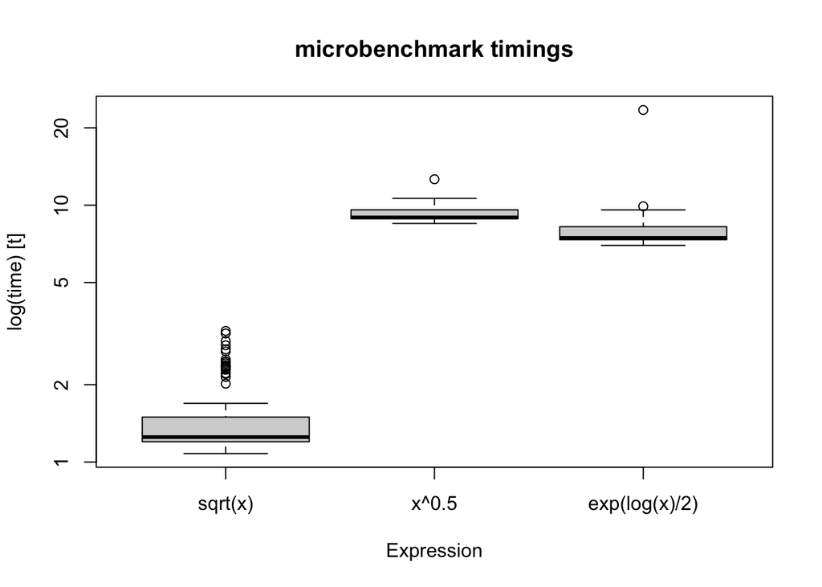

```r
boxplot(mbm)
```

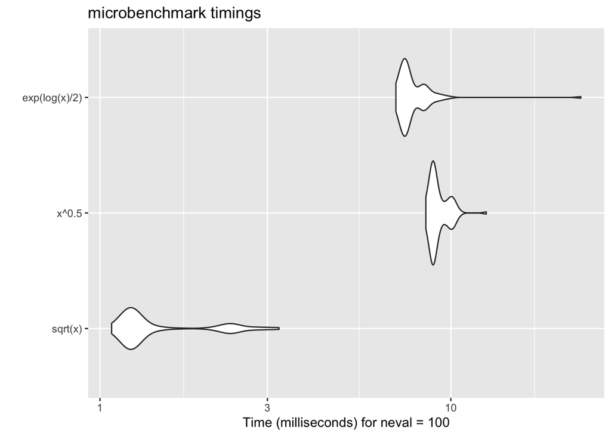

```r
autoplot(mbm)
```

### 4.3 `bench`

The `bench` package is another tool for microbenchmarking. The output is a tibble:

```r
library(bench)

(lb <- bench::mark(
  sqrt(x),
  x ^ 0.5,
  exp(log(x) / 2)
))
```

```
# A tibble: 3 × 6
  expression         min   median `itr/sec` mem_alloc `gc/sec`
  <bch:expr>    <bch:tm> <bch:tm>     <dbl> <bch:byt>    <dbl>
1 sqrt(x)       799.17µs   1.14ms      882.    7.63MB    223.
2 x^0.5           8.47ms   9.03ms      110.    7.63MB     15.4
3 exp(log(x)/2)   7.03ms   7.48ms      133.    7.63MB     18.6
```

To visualize the result

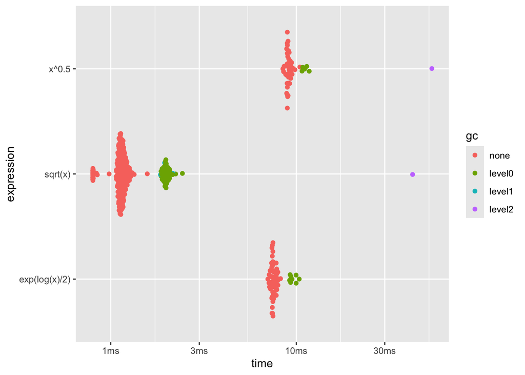

```r
plot(lb)
```

It is colored according to GC (garbage collection) levels.

## 5 Profiling

> Premature optimization is the root of all evil (or at least most of it) in programming.  
> -Don Knuth

Sources:

- https://adv-r.hadley.nz/perf-measure.html#profiling
- https://rstudio.github.io/profvis/
- https://support.rstudio.com/hc/en-us/articles/218221837-Profiling-with-RStudio

### 5.1 Example: profiling time

First generate test data:

```r
times <- 4e5
cols <- 150
data <- as.data.frame(x = matrix(rnorm(times * cols, mean = 5), ncol = cols))
data <- cbind(id = paste0("g", seq_len(times)), data)
head(data)
```

```
  id       V1       V2       V3       V4       V5       V6       V7       V8
1 g1 2.981836 4.164464 4.982529 4.978820 4.506594 3.079991 5.238585 4.653013
2 g2 5.536191 4.384690 5.591328 5.138394 5.304472 6.762579 5.236342 3.993085
3 g3 6.253099 4.689157 5.348821 5.224658 4.056211 5.247272 5.821576 4.396116
4 g4 4.973298 4.303862 4.401444 4.924181 5.620129 4.859185 5.935425 5.275132
5 g5 5.175552 6.216958 4.507430 5.005521 4.646542 3.579104 5.450840 7.496288
6 g6 5.631040 4.192790 5.897205 3.659010 3.782807 5.744241 5.417479 5.401910
        V9      V10      V11      V12      V13      V14      V15      V16
1 3.073927 4.947221 6.012135 4.995005 4.332740 5.808566 5.942925 5.740147
2 3.466410 5.599474 3.072913 3.103572 5.551738 4.615626 4.900277 5.171706
3 4.119978 4.924273 4.459582 5.993028 4.771276 4.760016 3.989738 5.098273
4 4.830882 3.994135 3.521508 4.141499 4.464089 5.194641 5.732664 3.115748
5 4.054059 5.110014 4.311404 5.533032 4.005842 5.117912 6.057117 5.035900
6 6.158850 3.221128 3.652466 5.278264 6.078092 4.497457 5.862068 4.235378
       V17      V18      V19      V20      V21      V22      V23      V24
```

[output cut: 118 more lines]

Original code for centering columns of a dataframe:

```r
library(profvis)
profvis({
  # Store in another variable for this run
  data1 <- data

  # Get column means
  means <- apply(data1[, names(data1) != "id"], 2, mean)

  # Subtract mean from each column
  for (i in seq_along(means)) {
    data1[, names(data1) != "id"][, i] <-
      data1[, names(data1) != "id"][, i] - means[i]
  }
})
```

[interactive chart not shown]

Profile `apply` vs `colMeans` vs `lapply` vs `vapply`:

```r
profvis({
  data1 <- data
  # Four different ways of getting column means
  means <- apply(data1[, names(data1) != "id"], 2, mean)
  means <- colMeans(data1[, names(data1) != "id"])
  means <- lapply(data1[, names(data1) != "id"], mean)
  means <- vapply(data1[, names(data1) != "id"], mean, numeric(1))
})
```

[interactive chart not shown]

We decide to use `vapply`:

```r
profvis({
  data1 <- data
  means <- vapply(data1[, names(data1) != "id"], mean, numeric(1))

  for (i in seq_along(means)) {
    data1[, names(data1) != "id"][, i] <- data1[, names(data1) != "id"][, i] - means[i]
  }
})
```

[interactive chart not shown]

Calculate mean and center in one pass:

```r
profvis({
 data1 <- data

 # Given a column, normalize values and return them
 col_norm <- function(col) {
   return(col - mean(col))
 }

 # Apply the normalizer function over all columns except id
 data1[, names(data1) != "id"] <-
   lapply(data1[, names(data1) != "id"], col_norm)
})
```

[interactive chart not shown]

### 5.2 Example: profiling memory

Original code for cumulative sums:

```r
profvis({
  data <- data.frame(value = runif(1e6))

  data$sum[1] <- data$value[1]
  for (i in seq(2, nrow(data))) {
    data$sum[i] <- data$sum[i-1] + data$value[i]
  }
})
```

[interactive chart not shown]

Write a function to avoid expensive indexing by `$`:

```r
profvis({
  csum <- function(x) {
    if (length(x) < 2) return(x)

    sum <- x[1]
    for (i in seq(2, length(x))) {
      sum[i] <- sum[i-1] + x[i]
    }
    return(sum)
  }
  data <- data.frame(value = runif(1e6))
  data$sum <- csum(data$value)
})
```

[interactive chart not shown]

Pre-allocate vector:

```r
profvis({
  csum2 <- function(x) {
    if (length(x) < 2) return(x)

    sum <- numeric(length(x))  # Preallocate
    sum[1] <- x[1]
    for (i in seq(2, length(x))) {
      sum[i] <- sum[i-1] + x[i]
    }
    sum
  }
  data <- data.frame(value = runif(1e6))
  data$sum <- csum2(data$value)
})
```

[interactive chart not shown]

### 5.3 Advice

Modularize big projects into small functions. Profile functions as early and as frequently as possible.

## 6 Debugging

Learning sources:

- Video: https://vimeo.com/99375765
- *Advanced R*: https://adv-r.hadley.nz/debugging.html
- breakpoint
- step in/through function
- `browser()`
- `traceback()`
- `options(error = browser)`, `options(error = NULL)`, `Debug` -> `On Error` -> `Break in Code`